# Ford GoBike Bike sharing data analysis 2017 - 2019

## Preliminary Wrangling

```python
# import packages

from requests import get
from zipfile import ZipFile
from io import BytesIO
from os import listdir
import numpy as np
import pandas as pd
import matplotlib.pyplot as plt
import seaborn as sb
from datetime import datetime as dt
from matplotlib import colors
from geopy.distance import vincenty

%matplotlib inline
```

### Gather Ford Bikes Data.

In this section i will programatically download all the files from [fordgobike-data](https://s3.amazonaws.com/fordgobike-data/index.html) and merge all the data sets for wrangling.

**2017 Data files**

```python
pd.read_csv('https://s3.amazonaws.com/fordgobike-data/2017-fordgobike-tripdata.csv').to_csv('data_files/2017_tripdata.csv')
```

**2018 Data files**

```python
for month in range(1,13):
    month_num = str(month).zfill(2)

    data_url = 'https://s3.amazonaws.com/fordgobike-data/2018' + month_num + '-fordgobike-tripdata.csv.zip'
    response = get(data_url)

    # Open zip file with rw rights
    unzipped_file = ZipFile(BytesIO(response.content))

    # Extract files into folder
    unzipped_file.extractall('data_files')
```

**2019 Data files**

```python
for month in range(1,5):
    month_num = str(month).zfill(2)

    data_url = 'https://s3.amazonaws.com/fordgobike-data/2019' + month_num + '-fordgobike-tripdata.csv.zip'
    response = get(data_url)

    # Open zip file with rw rights
    unzipped_file = ZipFile(BytesIO(response.content))

    # Extract files into folder
    unzipped_file.extractall('data_files')
```

**Merge all files**

```python
all_files = []
for file in listdir('data_files'):
    all_files.append(pd.read_csv('data_files/'+file))
master_df = pd.concat(all_files)

master_df.to_csv('data_files/master_data.csv')
```

```python
df = pd.read_csv('data_files/master_data.csv')
```

```python
df.info()
```

```
<class 'pandas.core.frame.DataFrame'>
RangeIndex: 3254325 entries, 0 to 3254324
Data columns (total 18 columns):
Unnamed: 0                 int64
Unnamed: 0.1               float64
bike_id                    int64
bike_share_for_all_trip    object
duration_sec               int64
end_station_id             float64
end_station_latitude       float64
end_station_longitude      float64
end_station_name           object
end_time                   object
member_birth_year          float64
member_gender              object
start_station_id           float64
start_station_latitude     float64
start_station_longitude    float64
start_station_name         object
start_time                 object
user_type                  object
dtypes: float64(8), int64(3), object(7)
memory usage: 446.9+ MB
```

After merging all the datasets into a single master data file, we have 3254325 rows, and 18 columns in the new dataset. This includes data from 2017 to 2019 April.

**Main feature of the dataset include;**

- member_birth_year : Birth year of a user
- duration_sec : duration
- start_station_latitude
- start_station_longitude

The dataset extends through 3 years;2017, 2018 and 2019. With this period we ll be able to analyse the service growth.

#### Cleaning Tasks

- End time and Start time are string data types
- Missing member birth year
- Missing gender values
- Unamed columns
- Missing bike_share_for_all_trip values

## Univariate Exploration

```python
#define a base color for plots
base_color = sb.color_palette()[0]
```

Convert End time and Start time to datetime datatype

```python
df['start_time']=pd.to_datetime(df['start_time'])
df['end_time']=pd.to_datetime(df['end_time'])
```

drop row with any missing birth year calculate member age

```python
df = df[~df['member_birth_year'].isnull()]
```

```python
#calculate member age
df['user_age'] = 2019 - df['member_birth_year']
```

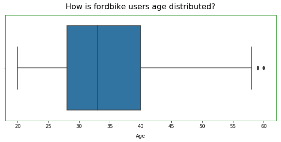

```python
#VISUAL to analyse the age distibution
# bins = np.arange(0, df['user_age'].max()+5, 5)
# plt.hist(data = df, x = 'user_age', bins = bins);

plt.figure(figsize=(10,4))
sb.boxplot( data = df, x='user_age', color=base_color)
plt.title("How is fordbike users age distributed?", fontsize=16, y=1.03)
plt.xlabel("Age", fontsize=10, labelpad=10);
```

**We filter outlier users between the age of 20 t0 60 years**

```python
df = df[(df['user_age'] >= 20) & (df['user_age'] <= 60)]
```

```python
df['user_age_group'] = df['user_age'].apply(lambda x: '10-20' if 10<x<=20
                                                  else '20-30' if 20<x<=30
                                                  else '30-40' if 30<x<=40
                                                  else '40-50' if 40<x<=50
                                                  else '50-60' if 50<x<=60
                                                  else x)
```

```python
#Define time periods
df['year'] = df['start_time'].dt.year.astype(int)
df['month'] = df['start_time'].dt.month.astype(int)
df['year_month'] = df['start_time'].map(lambda x: x.strftime('%Y-%m'))
df['day']=df['start_time'].dt.strftime("%A")
df['time_hour']=df['start_time'].dt.hour
```

Calculate the number of bike rides per day

**Which days of the week are users making most trips?**

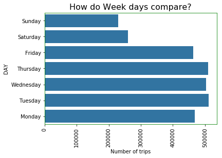

```python
# week_day_counts = df.groupby('day')['bike_id'].size().reset_index()
sb.countplot(data = df, y = 'day',color = base_color);
plt.xticks(rotation = 90);
plt.title('How do Week days compare?' , fontsize=16);
plt.xlabel('Number of trips');
plt.ylabel('DAY');
```

Most trips are made during weekdays. Fordbike service is mostly used to commute to work.

**Which hours are most frequent?**

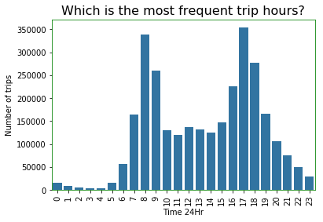

```python
sb.countplot(data = df, x = 'time_hour',color = base_color);
plt.xticks(rotation = 90);
plt.title('Which is the most frequent trip hours?', fontsize= 16);
plt.xlabel('Time 24Hr');
plt.ylabel('Number of trips');
```

Most frequent trip hours are 0700hrs - 0900hrs and 1600hrs and 1900hrs. This is are the time most users are commuting to work and back home repectively.

**How do user genders compare to bike usage?**

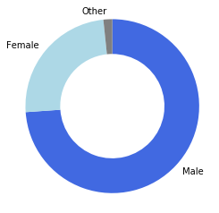

```python
gender_counts = df['member_gender'].value_counts()
plt.pie(gender_counts, labels = gender_counts.index, startangle = 90,
        counterclock = False, colors =['royalblue','lightblue','grey'], wedgeprops = {'width' : 0.4});
plt.axis('square');
```

Most users are of male gender

Drop unnamed columns

```python
df.drop(['Unnamed: 0', 'Unnamed: 0.1'], axis=1, inplace=True)
```

## Bivariate Exploration

**How does Age Group and User Type compare?**

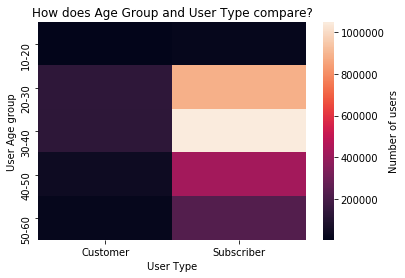

```python
age_counts = df.groupby(['user_age_group', 'user_type']).size()
age_counts = age_counts.reset_index(name = 'count')
age_counts = age_counts.pivot(index = 'user_age_group', columns = 'user_type', values = 'count')

sb.heatmap(age_counts,cbar_kws={'label': 'Number of users'});
plt.ylabel('User Age group')
plt.xlabel('User Type')
plt.title('How does Age Group and User Type compare?');
```

Most bike users are of the age group 30-40 and are subscribers.

**How does bike rides trend over time?**

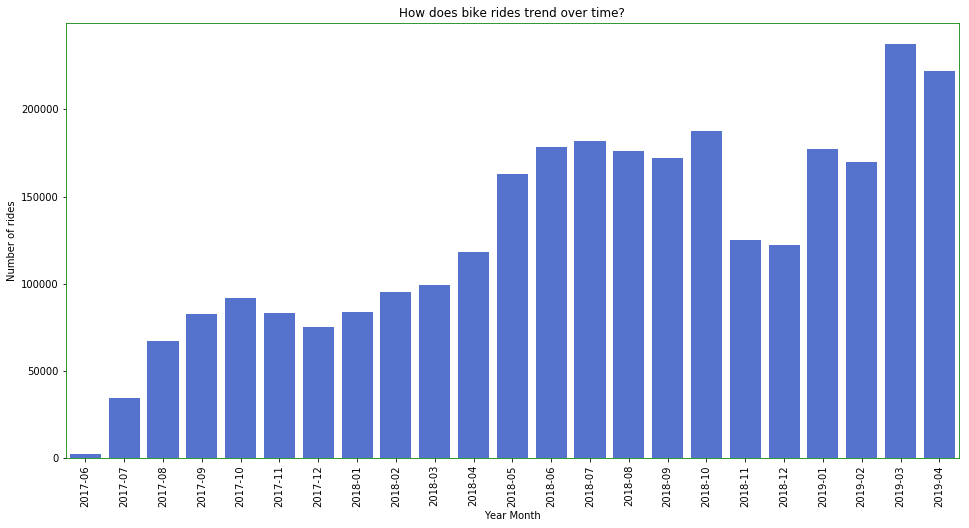

```python
plt.figure(figsize=(16,8))
sb.countplot(data = df.sort_values(by='year_month'), x='year_month', color="royalblue" )
plt.title('How does bike rides trend over time?')
plt.xlabel('Year Month')
plt.ylabel('Number of rides')
plt.xticks(rotation = 90);
```

```python
bike_share = df[df['bike_share_for_all_trip']=='Yes'].groupby(['year_month', 'user_age_group']).agg({'bike_id':'count'}).reset_index()
```

**How does age groups compare in number of bike rides over time?**

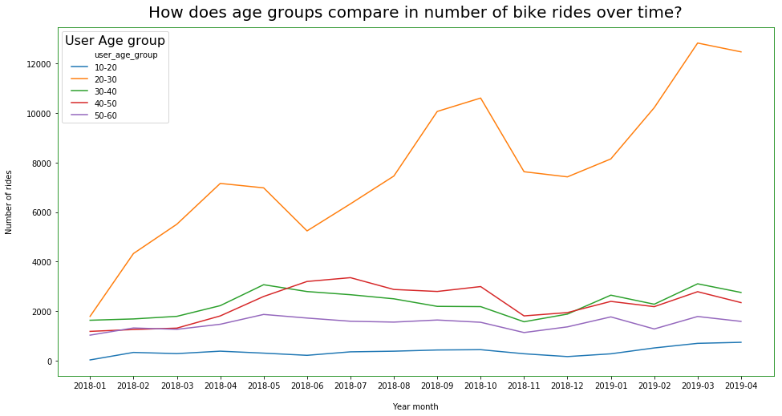

```python
plt.figure(figsize=(16,8))
ax = sb.lineplot(data = bike_share, x='year_month', y='bike_id', hue='user_age_group')
plt.title("How does age groups compare in number of bike rides over time?", fontsize=20, y=1.015)
plt.xlabel('Year month', labelpad=16)
plt.ylabel('Number of rides', labelpad=16)
leg = ax.legend()
leg.set_title('User Age group',prop={'size':16})
```

According to the above analysis, 20-30 years age group has the highest bike riders with an increasing trend. All other age groups have maintained less than 4,000 users over time. We can conclude that bikes are highly used by the youthful age.

**How does the bike rides compare on average over the years?**

```python
df_year = df.groupby(['year']).agg({'bike_id':'mean'}).rename(columns={'bike_id':'no_of_rides'}).reset_index()
df_year['no_of_rides'] = df_year['no_of_rides'].astype(int)
```

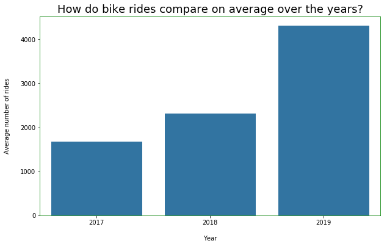

```python
plt.figure(figsize=(10,6))
sb.barplot(df_year['year'], df_year['no_of_rides'], color=base_color);
plt.title('How do bike rides compare on average over the years?', fontsize=18, y=1)
plt.xlabel('Year', labelpad=16)
plt.ylabel('Average number of rides', labelpad=16)
# plt.box(color=base_color)
plt.rc('axes',edgecolor='green')
# ax = plt.gca()
# plt.xticks(rotation=90);
```

Accorfing to the visual above, there is a steady increase in the number of rides over the years.

**Which gender is more active in the bike riding service?**

```python
df.head()
```

|  | bike_id | bike_share_for_all_trip | duration_sec | end_station_id | end_station_latitude | end_station_longitude | end_station_name | end_time | member_birth_year | member_gender | ... | start_station_name | start_time | user_type | user_age | user_age_group | year | month | year_month | day | time_hour |
| --- | --- | --- | --- | --- | --- | --- | --- | --- | --- | --- | --- | --- | --- | --- | --- | --- | --- | --- | --- | --- | --- |
| 0 | 96 | NaN | 80110 | 43.0 | 37.778768 | -122.415929 | San Francisco Public Library (Grove St at Hyde... | 2018-01-01 15:12:50.245 | 1987.0 | Male | ... | Laguna St at Hayes St | 2017-12-31 16:57:39.654 | Customer | 32.0 | 30-40 | 2017 | 12 | 2017-12 | Sunday | 16 |
| 1 | 88 | NaN | 78800 | 96.0 | 37.766210 | -122.426614 | Dolores St at 15th St | 2018-01-01 13:49:55.617 | 1965.0 | Female | ... | Yerba Buena Center for the Arts (Howard St at ... | 2017-12-31 15:56:34.842 | Customer | 54.0 | 50-60 | 2017 | 12 | 2017-12 | Sunday | 15 |
| 4 | 3167 | NaN | 43603 | 247.0 | 37.867789 | -122.265896 | Fulton St at Bancroft Way | 2018-01-01 02:29:57.571 | 1997.0 | Female | ... | Bancroft Way at Telegraph Ave | 2017-12-31 14:23:14.001 | Subscriber | 22.0 | 20-30 | 2017 | 12 | 2017-12 | Sunday | 14 |
| 6 | 3539 | NaN | 4507 | 259.0 | 37.866249 | -122.299371 | Addison St at Fourth St | 2018-01-01 01:04:35.619 | 1991.0 | Female | ... | Addison St at Fourth St | 2017-12-31 23:49:28.422 | Customer | 28.0 | 20-30 | 2017 | 12 | 2017-12 | Sunday | 23 |
| 12 | 2311 | NaN | 2183 | 24.0 | 37.789677 | -122.390428 | Spear St at Folsom St | 2018-01-01 00:29:18.743 | 1990.0 | Male | ... | San Francisco Caltrain Station 2 (Townsend St... | 2017-12-31 23:52:55.581 | Subscriber | 29.0 | 20-30 | 2017 | 12 | 2017-12 | Sunday | 23 |

5 rows × 23 columns

```python
gender_df = df[df['member_gender'].isin(['Male', 'Female'])].sort_values(by=['year_month', 'member_gender'])
```

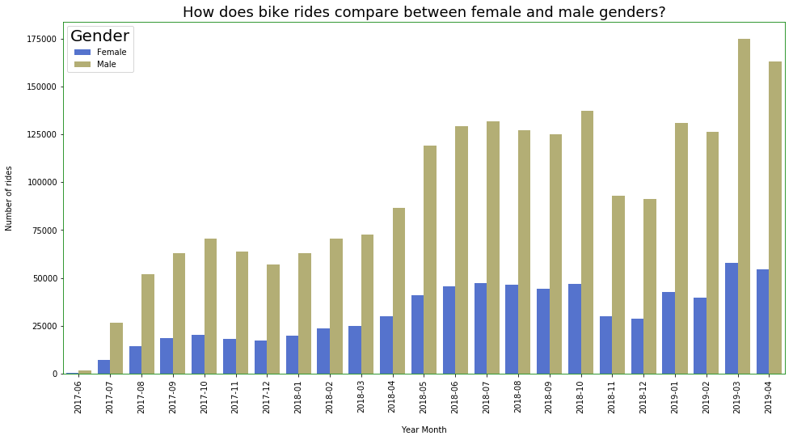

```python
plt.figure(figsize=(16,8))
color = {'Male': 'darkkhaki','Female': 'royalblue'}
ax = sb.countplot( data=gender_df, x='year_month', hue='member_gender', palette=color)
plt.title('How does bike rides compare between female and male genders?', fontsize=18, y=1)
plt.xlabel('Year Month', labelpad=16)
plt.ylabel('Number of rides', labelpad=16)
leg = ax.legend()
leg.set_title('Gender',prop={'size':20})
ax = plt.gca()
plt.xticks(rotation=90);
```

```python
df.head()
```

|  | bike_id | bike_share_for_all_trip | duration_sec | end_station_id | end_station_latitude | end_station_longitude | end_station_name | end_time | member_birth_year | member_gender | ... | start_station_name | start_time | user_type | user_age | user_age_group | year | month | year_month | day | time_hour |
| --- | --- | --- | --- | --- | --- | --- | --- | --- | --- | --- | --- | --- | --- | --- | --- | --- | --- | --- | --- | --- | --- |
| 0 | 96 | NaN | 80110 | 43.0 | 37.778768 | -122.415929 | San Francisco Public Library (Grove St at Hyde... | 2018-01-01 15:12:50.245 | 1987.0 | Male | ... | Laguna St at Hayes St | 2017-12-31 16:57:39.654 | Customer | 32.0 | 30-40 | 2017 | 12 | 2017-12 | Sunday | 16 |
| 1 | 88 | NaN | 78800 | 96.0 | 37.766210 | -122.426614 | Dolores St at 15th St | 2018-01-01 13:49:55.617 | 1965.0 | Female | ... | Yerba Buena Center for the Arts (Howard St at ... | 2017-12-31 15:56:34.842 | Customer | 54.0 | 50-60 | 2017 | 12 | 2017-12 | Sunday | 15 |
| 4 | 3167 | NaN | 43603 | 247.0 | 37.867789 | -122.265896 | Fulton St at Bancroft Way | 2018-01-01 02:29:57.571 | 1997.0 | Female | ... | Bancroft Way at Telegraph Ave | 2017-12-31 14:23:14.001 | Subscriber | 22.0 | 20-30 | 2017 | 12 | 2017-12 | Sunday | 14 |
| 6 | 3539 | NaN | 4507 | 259.0 | 37.866249 | -122.299371 | Addison St at Fourth St | 2018-01-01 01:04:35.619 | 1991.0 | Female | ... | Addison St at Fourth St | 2017-12-31 23:49:28.422 | Customer | 28.0 | 20-30 | 2017 | 12 | 2017-12 | Sunday | 23 |
| 12 | 2311 | NaN | 2183 | 24.0 | 37.789677 | -122.390428 | Spear St at Folsom St | 2018-01-01 00:29:18.743 | 1990.0 | Male | ... | San Francisco Caltrain Station 2 (Townsend St... | 2017-12-31 23:52:55.581 | Subscriber | 29.0 | 20-30 | 2017 | 12 | 2017-12 | Sunday | 23 |

5 rows × 23 columns

## Multivariate Exploration

**What time of the week do we have the highest number of rides?**

```python
df_subscribers = df[df['user_type'] == 'Subscriber']
df_customers = df[df['user_type'] == 'Customer']

subscribers_day_time_df = df_subscribers.groupby(['user_type','day', 'time_hour']).agg({'bike_id' : 'count'}).rename(columns={'bike_id':'no_of_rides'}).reset_index()
subscribers_day_time_df = subscribers_day_time_df.pivot_table(index='time_hour', columns='day', values='no_of_rides').astype(int)
customers_day_time_df = df_customers.groupby(['user_type','day', 'time_hour']).agg({'bike_id' : 'count'}).rename(columns={'bike_id':'no_of_rides'}).reset_index()
customers_day_time_df = customers_day_time_df.pivot_table(index='time_hour', columns='day', values='no_of_rides').astype(int)
```

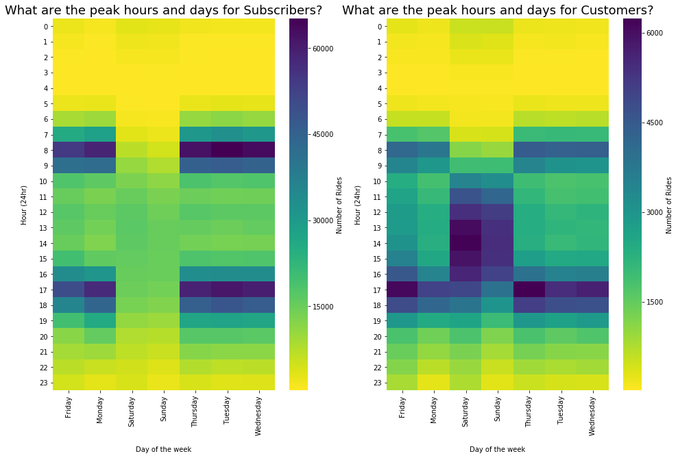

```python
plt.figure(figsize=(16,10))
plt.subplot(121)
sb.heatmap(subscribers_day_time_df, fmt='d',  cmap='viridis_r', annot_kws={"size": 12},  cbar_kws={'label': 'Number of Rides'})
plt.title("What are the peak hours and days for Subscribers?", y=1.2, fontsize=18)
plt.xlabel('Day of the week', labelpad=16)
plt.ylabel('Hour (24hr)', labelpad=16)
plt.yticks(rotation=360);

plt.subplot(122)
sb.heatmap(customers_day_time_df, fmt='d',  cmap='viridis_r', annot_kws={"size": 12},  cbar_kws={'label': 'Number of Rides'})
plt.title("What are the peak hours and days for Customers?", y=1.2, fontsize=18)
plt.xlabel('Day of the week', labelpad=16)
plt.ylabel('Hour (24hr)', labelpad=16)
plt.yticks(rotation=360);
```

Most rides are made at around 0800hrs in the morning and at 1700hours in the evening during week days for both subscribers and customers. This means most of the rides are made to and from work since weekend rides a relatively low. Subscribers highly use bike rides during weekdays and Customers have a high frequency of rides during the day on weekends.

```python
#Make a copy to use for further exploration
df.to_csv('edited_master_data.csv')
```